# LessonPace

#### The average time for differen plans by Grade

```
##                              plan_name Grade mean   n
## 1                          Custom Plan    PK  1.0   1
## 2                          Custom Plan    PS  2.0   2
## 3               T1 Addition Strategies    PK  3.0  54
## 4               T1 Addition Strategies    PS  2.5  22
## 5            T1 Classification/Sorting    PK  2.0   4
## 6                 T1 Comparative Value    PK  2.0  20
## 7                 T1 Comparative Value    PS  1.8  19
## 8                    T1 Compound Words    PK  2.3  34
## 9                    T1 Compound Words    PS  2.6  77
## 10                    T1 Conversations    PK  2.1  39
## 11                    T1 Conversations    PS  2.0  33
## 12                T1 ELL Units 2-4 DIP    PK  3.1   5
## 13                T1 ELL Units 2-4 DIP    PS  2.7   9
## 14               T1 ELL Units 9-10 DIP    PK  1.2   2
```

[output cut: 45 more lines]

*note: I first define diff as the value of Round_Last_lesson_Taught minus its corresponding average time. if the absolute value of diff is less than 0.3, then I define rate as equal, otherwise, if diff>0, I define rate as more and if diff<0, I define rate as less.*

#### Build linear regressions to study the relation between the lesson pace and PassRate

```r
model1= lm(PassRate~rate+Grade, data=pace1)
summary(model1)
```

```
##
## Call:
## lm(formula = PassRate ~ rate + Grade, data = pace1)
##
## Residuals:
##     Min      1Q  Median      3Q     Max
## -0.8339 -0.1515  0.1661  0.2363  0.2822
##
## Coefficients:
##             Estimate Std. Error t value Pr(>|t|)
## (Intercept)  0.83389    0.01937  43.044  < 2e-16 ***
## rateless    -0.04596    0.02360  -1.947   0.0517 .
## ratemore    -0.01571    0.02088  -0.753   0.4518
## GradePS     -0.07015    0.01759  -3.988 7.07e-05 ***
## ---
## Signif. codes:  0 '***' 0.001 '**' 0.01 '*' 0.05 '.' 0.1 ' ' 1
##
## Residual standard error: 0.297 on 1161 degrees of freedom
## Multiple R-squared:  0.01525,    Adjusted R-squared:  0.01271
## F-statistic: 5.994 on 3 and 1161 DF,  p-value: 0.0004717
```

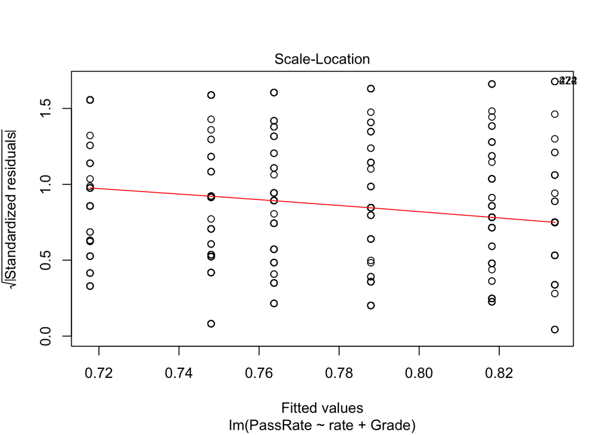

```r
plot(model1,which=3)
```

#### some viuslization

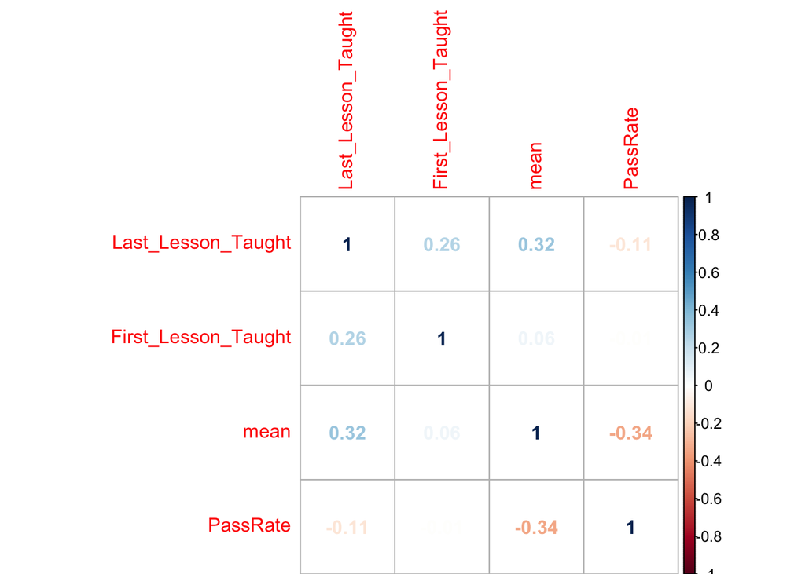

*According to the above correlation matrix, none of the numerical variables are highly linear correlated with PassRate*

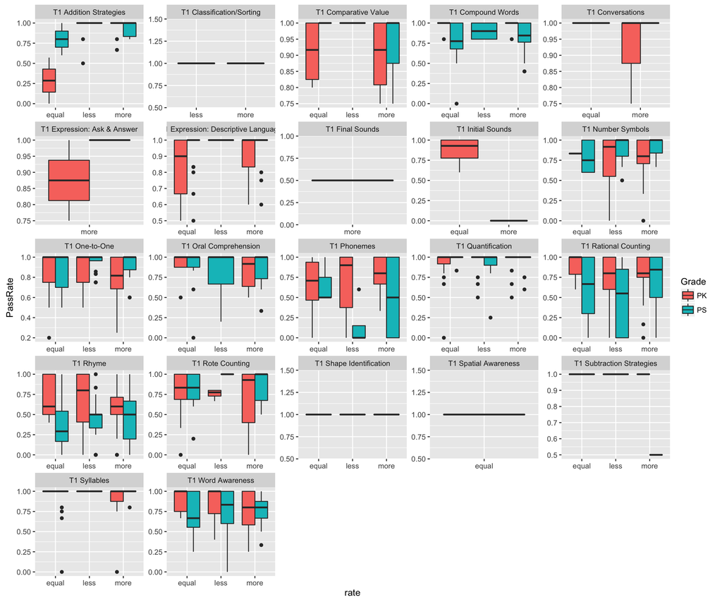

#### Build spline model (non-linear)

```
##
## Family: gaussian
## Link function: identity
##
## Formula:
## PassRate ~ s(Last_Lesson_Taught)
##
## Parametric coefficients:
##             Estimate Std. Error t value Pr(>|t|)
## (Intercept) 0.777867   0.008673   89.69   <2e-16 ***
## ---
## Signif. codes:  0 '***' 0.001 '**' 0.01 '*' 0.05 '.' 0.1 ' ' 1
##
## Approximate significance of smooth terms:
##                         edf Ref.df     F  p-value
## s(Last_Lesson_Taught) 2.582  3.239 6.952 7.92e-05 ***
## ---
## Signif. codes:  0 '***' 0.001 '**' 0.01 '*' 0.05 '.' 0.1 ' ' 1
##
## R-sq.(adj) =  0.0188   Deviance explained =  2.1%
## GCV = 0.087908  Scale est. = 0.087637  n = 1165
```

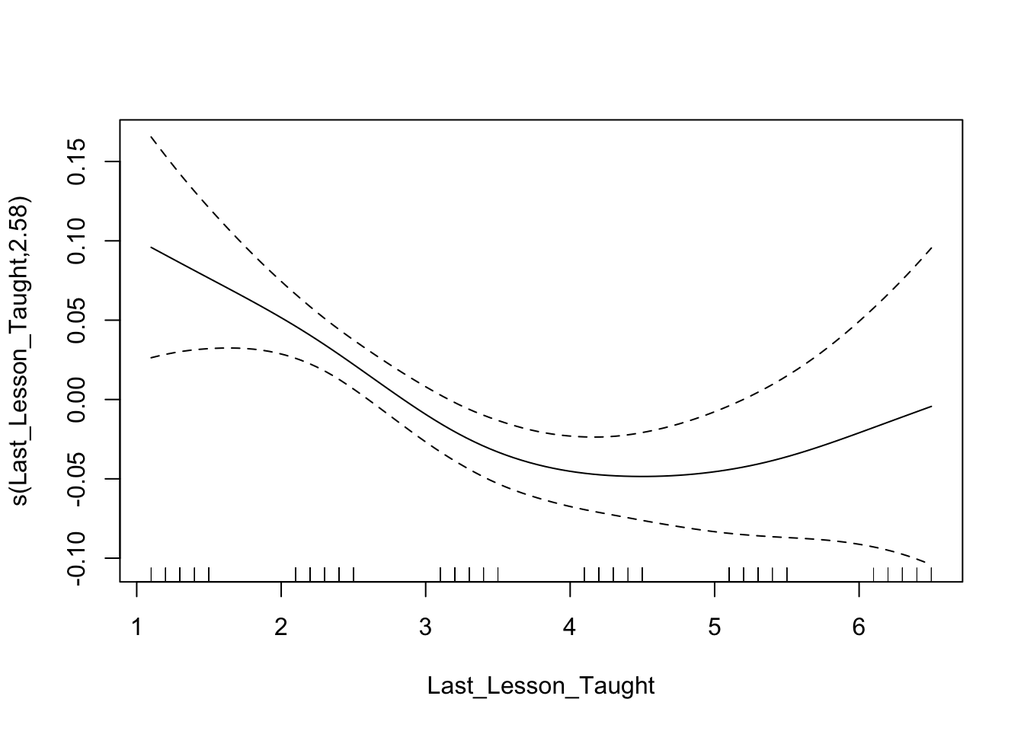

According to the result, the spline item of Last_Lesson_Taught significant affects on PassRate. The plot shows what kind of transformation applies on Last_Lesson_Taught.